# Worked examples of logistic regression

# Introduction

In this document, we will provide three worked examples of logistic regression using real data. Each example will demonstrate different aspects of logistic regression, including continuous and categorical variables, and a contingency table.

## Example 1: One Independent Continuous Variable

We will use the mtcars dataset to fit a logistic regression model with am (transmission: 0 = automatic, 1 = manual) as the response variable and wt (weight) as the independent variable.

```r
# Load necessary libraries
library(ggplot2)
# Load the mtcars dataset
data("mtcars")

# Fit logistic regression model
logit_model1 <- glm(am ~ wt, data = mtcars, family = binomial)

# Display the summary of the model
summary(logit_model1)
```

```
##
## Call:
## glm(formula = am ~ wt, family = binomial, data = mtcars)
##
## Coefficients:
##             Estimate Std. Error z value Pr(>|z|)
## (Intercept)   12.040      4.510   2.670  0.00759 **
## wt            -4.024      1.436  -2.801  0.00509 **
## ---
## Signif. codes:  0 '***' 0.001 '**' 0.01 '*' 0.05 '.' 0.1 ' ' 1
##
## (Dispersion parameter for binomial family taken to be 1)
##
##     Null deviance: 43.230  on 31  degrees of freedom
## Residual deviance: 19.176  on 30  degrees of freedom
## AIC: 23.176
##
## Number of Fisher Scoring iterations: 6
```

# Predicted Probabilities

We will create a plot to show how the predicted probabilities of having a manual transmission (am = 1) change according to the weight (wt).

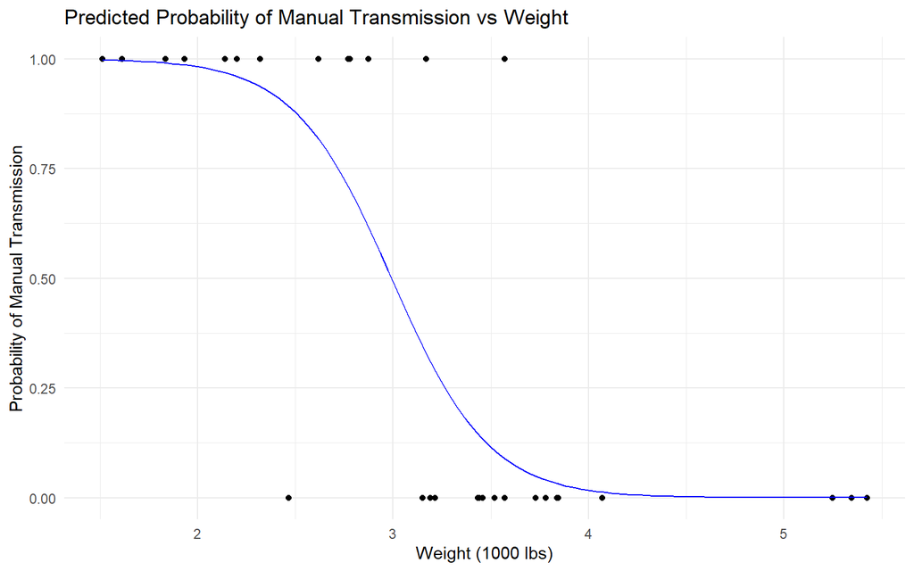

```r
# Create a data frame for predictions
pred_data <- data.frame(wt = seq(min(mtcars$wt), max(mtcars$wt), length.out = 100))
pred_data$prob <- predict(logit_model1, newdata = pred_data, type = "response")

# Plot the predicted probabilities
ggplot(mtcars, aes(x = wt, y = am)) +
  geom_point() +
  geom_line(data = pred_data, aes(x = wt, y = prob), color = "blue") +
  labs(title = "Predicted Probability of Manual Transmission vs Weight",
       x = "Weight (1000 lbs)",
       y = "Probability of Manual Transmission") +
  theme_minimal()
```

# t-test Comparison

We will perform a t-test to compare wt for different levels of am. For simplicity, we will divide am into two groups: automatic and manual.

```r
# Perform t-test
t_test <- t.test(wt ~ am, data = mtcars)

cat("t-test Results:\n")
```

```
## t-test Results:
```

```r
print(t_test)
```

```
##
##  Welch Two Sample t-test
##
## data:  wt by am
## t = 5.4939, df = 29.234, p-value = 6.272e-06
## alternative hypothesis: true difference in means between group 0 and group 1 is not equal to 0
## 95 percent confidence interval:
##  0.8525632 1.8632262
## sample estimates:
## mean in group 0 mean in group 1
##        3.768895        2.411000
```

# Boxplot of Results

We will create a boxplot to visualize the distribution of wt for the two transmission types.

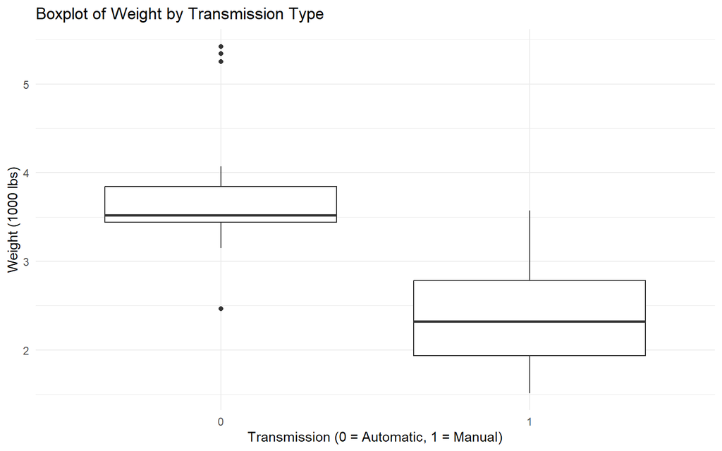

```r
# Create boxplot
ggplot(mtcars, aes(x = factor(am), y = wt)) +
  geom_boxplot() +
  labs(title = "Boxplot of Weight by Transmission Type",
       x = "Transmission (0 = Automatic, 1 = Manual)",
       y = "Weight (1000 lbs)") +
  theme_minimal()
```

## Example 2: Multiple Independent Variables

We will use the mtcars dataset to fit a logistic regression model with am as the response variable and wt (weight), hp (horsepower), and cyl (number of cylinders) as independent variables.

```r
# Fit logistic regression model
logit_model2 <- glm(am ~ wt + hp + factor(cyl), data = mtcars, family = binomial)

# Display the summary of the model
summary(logit_model2)
```

```
##
## Call:
## glm(formula = am ~ wt + hp + factor(cyl), family = binomial,
##     data = mtcars)
##
## Coefficients:
##               Estimate Std. Error z value Pr(>|z|)
## (Intercept)   18.09383    9.46271   1.912   0.0559 .
## wt           -10.67598    5.44182  -1.962   0.0498 *
## hp             0.10321    0.09606   1.074   0.2826
## factor(cyl)6   2.76575    3.15679   0.876   0.3810
## factor(cyl)8  -8.38896   13.16709  -0.637   0.5240
## ---
## Signif. codes:  0 '***' 0.001 '**' 0.01 '*' 0.05 '.' 0.1 ' ' 1
##
## (Dispersion parameter for binomial family taken to be 1)
##
##     Null deviance: 43.2297  on 31  degrees of freedom
## Residual deviance:  7.2554  on 27  degrees of freedom
## AIC: 17.255
##
## Number of Fisher Scoring iterations: 9
```

# Interpretation of Terms

The summary of the model provides the following information:

- Intercept: The log-odds of having a manual transmission when all predictors are zero.
- wt: The change in log-odds of having a manual transmission for a one-unit increase in wt, holding other variables constant.
- hp: The change in log-odds of having a manual transmission for a one-unit increase in hp, holding other variables constant.
- factor(cyl): The change in log-odds of having a manual transmission for different levels of cyl, holding other variables constant.

## Example 3: Contingency Table

```r
# Load the HairEyeColor dataset
data("HairEyeColor")

# Convert the dataset to a data frame
hair_eye <- as.data.frame(HairEyeColor)

# Filter the data to include only blue and brown eyes
hair_eye_filtered <- subset(hair_eye, Eye %in% c("Blue", "Brown"))

# Create a binary response variable for eye color (Blue vs. Brown)
hair_eye_filtered$EyeBinary <- ifelse(hair_eye_filtered$Eye == "Blue", 1, 0)

# Fit logistic regression model
logit_model3 <- glm(EyeBinary ~ Hair + Sex, data = hair_eye_filtered, family = binomial, weights = Freq)

# Display the summary of the model
summary(logit_model3)
```

```
##
## Call:
## glm(formula = EyeBinary ~ Hair + Sex, family = binomial, data = hair_eye_filtered,
##     weights = Freq)
##
## Coefficients:
##             Estimate Std. Error z value Pr(>|z|)
## (Intercept)  -0.9846     0.2747  -3.585 0.000337 ***
## HairBrown     0.8777     0.2934   2.992 0.002774 **
## HairRed       0.8214     0.4055   2.026 0.042783 *
## HairBlond     3.9421     0.4739   8.319  < 2e-16 ***
## SexFemale    -0.5011     0.2261  -2.217 0.026650 *
## ---
## Signif. codes:  0 '***' 0.001 '**' 0.01 '*' 0.05 '.' 0.1 ' ' 1
##
## (Dispersion parameter for binomial family taken to be 1)
##
##     Null deviance: 602.98  on 15  degrees of freedom
## Residual deviance: 473.29  on 11  degrees of freedom
## AIC: 483.29
##
## Number of Fisher Scoring iterations: 5
```

### Summary and Explanation

The summary of the model provides the following information:

- Intercept: The log-odds of having blue eyes for individuals with black hair and male sex (reference categories).
- Hair: The change in log-odds of having blue eyes for different hair colors compared to the reference category (black hair), holding sex constant.
- SexFemale: The change in log-odds of having blue eyes for females compared to males, holding hair color constant.

```r
# Display the coefficients in a more interpretable form
exp(coef(logit_model3))
```

```
## (Intercept)   HairBrown     HairRed   HairBlond   SexFemale
##   0.3735741   2.4053979   2.2736490  51.5271575   0.6058543
```

The coefficients in the model can be exponentiated to interpret them as odds ratios. The odds ratios indicate how the odds of having blue eyes change for different hair colors and for females compared to males.

# Exercises

## Exercise 1: Fit a Logistic Regression Model

Fit a logistic regression model with `am` (transmission: 0 = automatic, 1 = manual) as the response variable and `hp` (horsepower) as the independent variable. Display the summary of the model.

**Show Solution**

```r
# Fit logistic regression model
logit_model <- glm(am ~ hp, data = mtcars, family = binomial)
summary(logit_model)
```

```
##
## Call:
## glm(formula = am ~ hp, family = binomial, data = mtcars)
##
## Coefficients:
##              Estimate Std. Error z value Pr(>|z|)
## (Intercept)  0.776614   0.915429   0.848    0.396
## hp          -0.008117   0.006074  -1.336    0.181
##
## (Dispersion parameter for binomial family taken to be 1)
##
##     Null deviance: 43.230  on 31  degrees of freedom
## Residual deviance: 41.228  on 30  degrees of freedom
## AIC: 45.228
##
## Number of Fisher Scoring iterations: 4
```

## Exercise 2: Model Predictions

Predict the probability of am being 1 (manual transmission) for a car with 110 horsepower using the logistic regression model from Exercise 1. Display the predicted probability.

**Show Solution**

```r
# Solution
new_data <- data.frame(hp = 110)
predicted_prob <- predict(logit_model, newdata = new_data, type = "response")
predicted_prob
```

```
##         1
## 0.4709653
```

## Exercise 3: Model Accuracy

Calculate the accuracy of the logistic regression model from Exercise 1 on the mtcars dataset.

**Show Solution**

```r
# Solution
predicted_classes <- ifelse(predict(logit_model, type = "response") > 0.5, 1, 0)
accuracy <- mean(predicted_classes == mtcars$am)
accuracy
```

```
## [1] 0.71875
```

# Conclusion